# Chapter 07: Exploratory Graphs

Nutsa Nanuashvili

```r
suppressMessages(library(tidyverse))
```

Import data Air pollution (average PM2.5)

```r
path = "C:/Users/nutsa/Documents/Projects/EDA_PaiR/data/"
polut_data = readr::read_csv( paste0 (path, "avgpm25.csv"),
                 col_types = cols( pm25 = col_double(),
  fips = col_character(),
  region = col_factor(),
  longitude = col_double(),
  latitude = col_double() ) )
```

Check data

```r
glimpse(polut_data)
```

```
## Rows: 576
## Columns: 5
## $ pm25      <dbl> 9.771185, 9.993817, 10.688618, 11.337424, 12.119764, 10.8...
## $ fips      <chr> "01003", "01027", "01033", "01049", "01055", "01069", "01...
## $ region    <fct> east, east, east, east, east, east, east, east, east, eas...
## $ longitude <dbl> -87.74826, -85.84286, -87.72596, -85.79892, -86.03212, -8...
## $ latitude  <dbl> 30.59278, 33.26581, 34.73148, 34.45913, 34.01860, 31.1897...
```

```r
levels(polut_data$region)
```

```
## [1] "east" "west"
```

```r
slice_sample(polut_data, n = 10)
```

```
## # A tibble: 10 x 5
##     pm25 fips  region longitude latitude
##    <dbl> <chr> <fct>      <dbl>    <dbl>
##  1  4.57 56039 west      -111.      43.6
##  2  7.51 41059 west      -119.      45.6
##  3  8.94 26005 east       -85.9     42.6
##  4  7.58 12111 east       -80.4     27.3
##  5 11.9  21101 east       -87.6     37.8
##  6  9.78 50021 east       -73.1     43.6
##  7 11.1  05131 east       -94.4     35.3
##  8  9.68 06067 west      -121.      38.6
##  9 11.8  21093 east       -85.9     37.7
## 10  5.71 33001 east       -71.4     43.5
```

### Features

- `fips` - 5-digit code indicating the county
- `pm25` - average level
- `region` - region of the country in which the county resides
- `longitude` and `latitude` of the centroid for that county

```r
summary(polut_data)
```

```
##       pm25            fips            region      longitude
##  Min.   : 3.383   Length:576         east:442   Min.   :-158.04
##  1st Qu.: 8.549   Class :character   west:134   1st Qu.: -97.38
##  Median :10.047   Mode  :character              Median : -87.37
##  Mean   : 9.836                                 Mean   : -91.65
##  3rd Qu.:11.356                                 3rd Qu.: -80.72
##  Max.   :18.441                                 Max.   : -68.26
##     latitude
##  Min.   :19.68
##  1st Qu.:35.30
##  Median :39.09
##  Mean   :38.56
##  3rd Qu.:41.75
##  Max.   :64.82
```

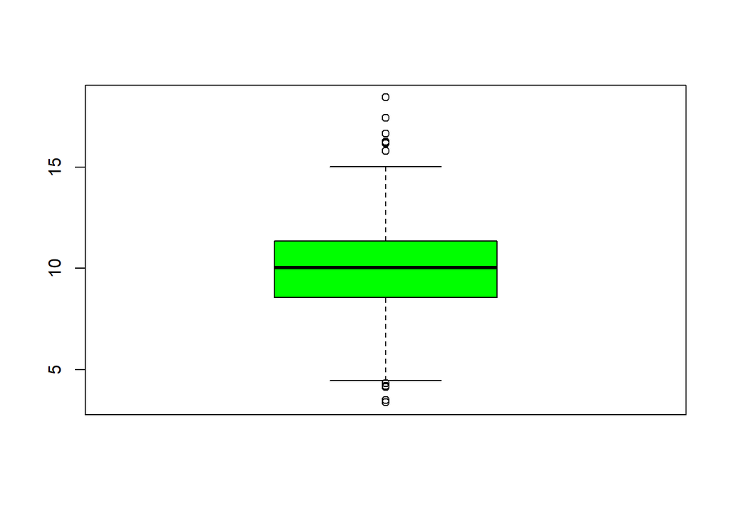

```r
boxplot(polut_data$pm25, col = "green" )
```

Drow a line at national standard of 12 micrograms

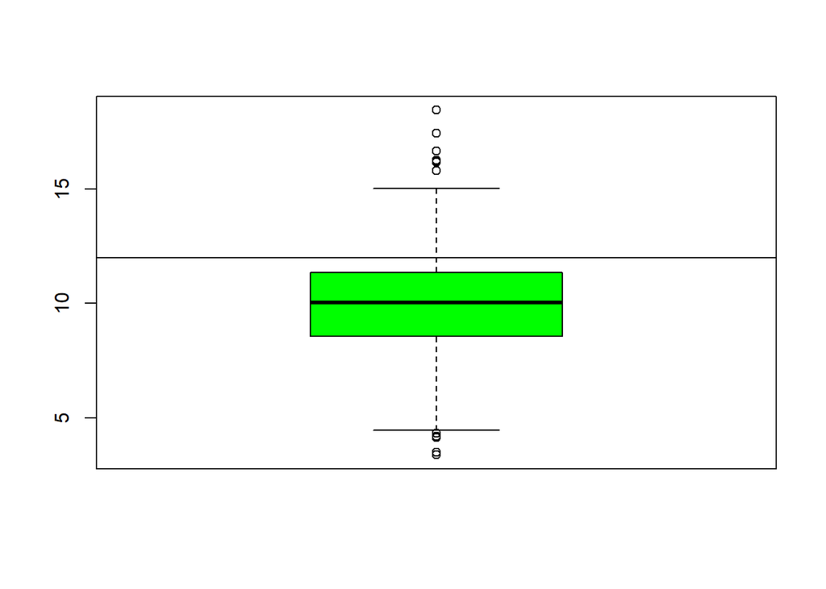

```r
boxplot(polut_data$pm25, col = "green")
abline(h = 12)
```

Look at the points above pm25 = 15, because the standard must not exeed 12 micrograms

```r
polut_data %>%
  filter(pm25 > 15)
```

```
## # A tibble: 8 x 5
##    pm25 fips  region longitude latitude
##   <dbl> <chr> <fct>      <dbl>    <dbl>
## 1  16.2 06019 west       -120.     36.6
## 2  15.8 06029 west       -119.     35.3
## 3  18.4 06031 west       -120.     36.2
## 4  16.7 06037 west       -118.     34.1
## 5  15.0 06047 west       -121.     37.2
## 6  17.4 06065 west       -117.     33.8
## 7  16.3 06099 west       -121.     37.6
## 8  16.2 06107 west       -119.     36.2
```

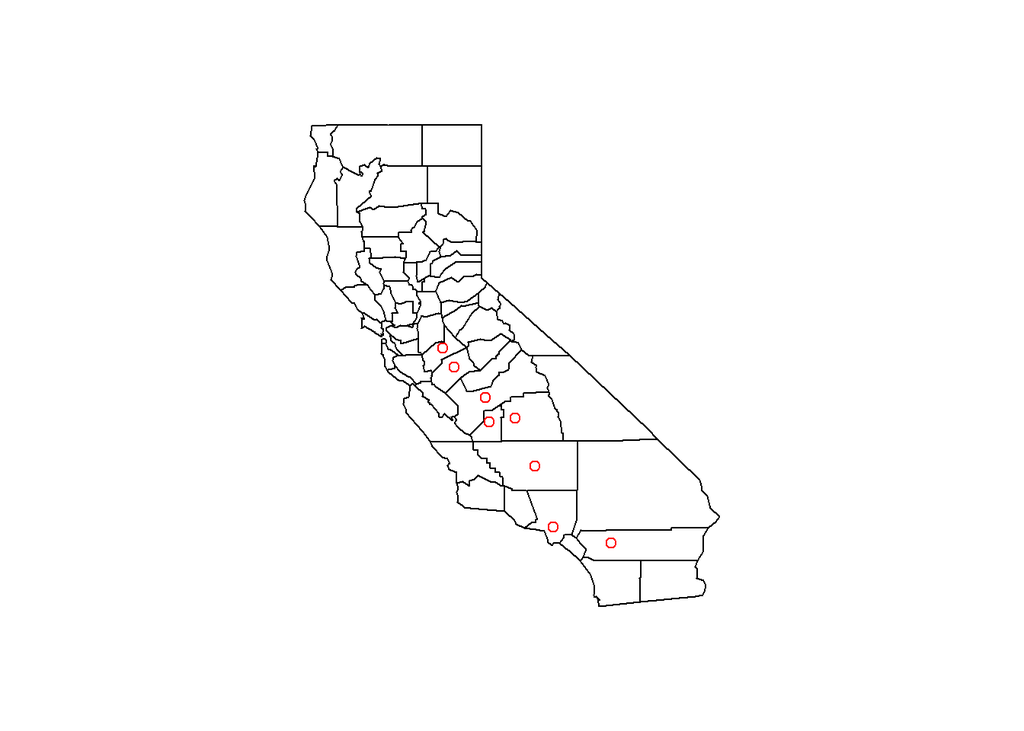

```r
suppressMessages(library(maps))

maps::map("county", "california")
with(filter(polut_data, pm25 >15), points (longitude, latitude, col = "red" ))
```

### Histogram

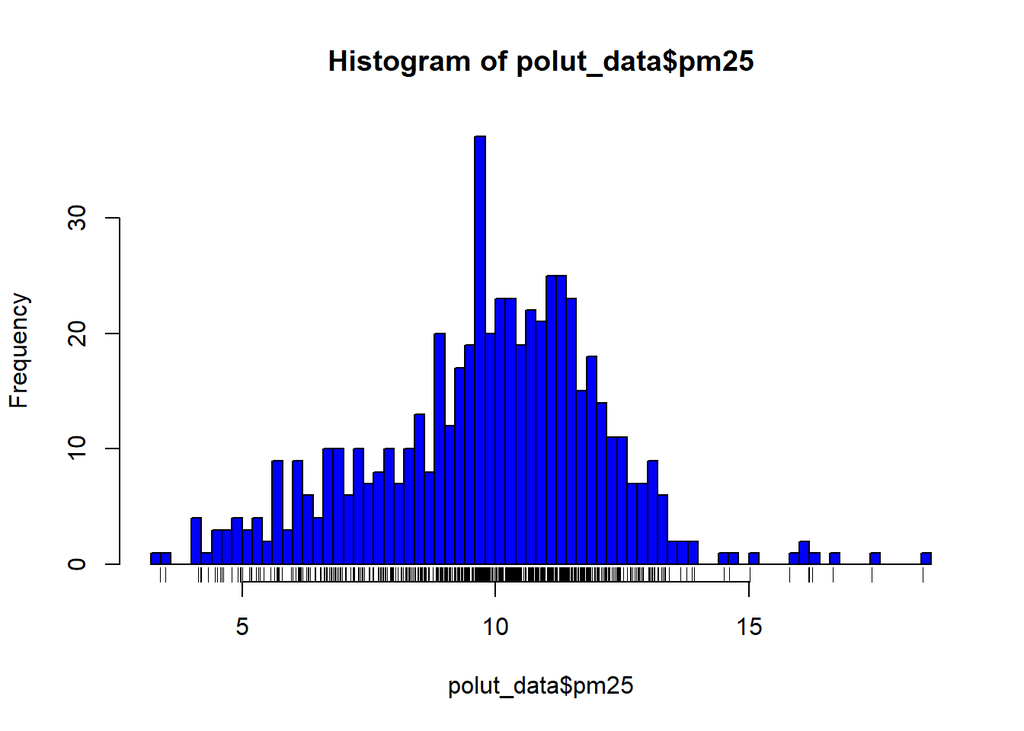

```r
hist(polut_data$pm25, col = "blue", breaks = 100)
rug(polut_data$pm25)
```

Draw two lines, one at the median of the data and one at 12, the level of the standard

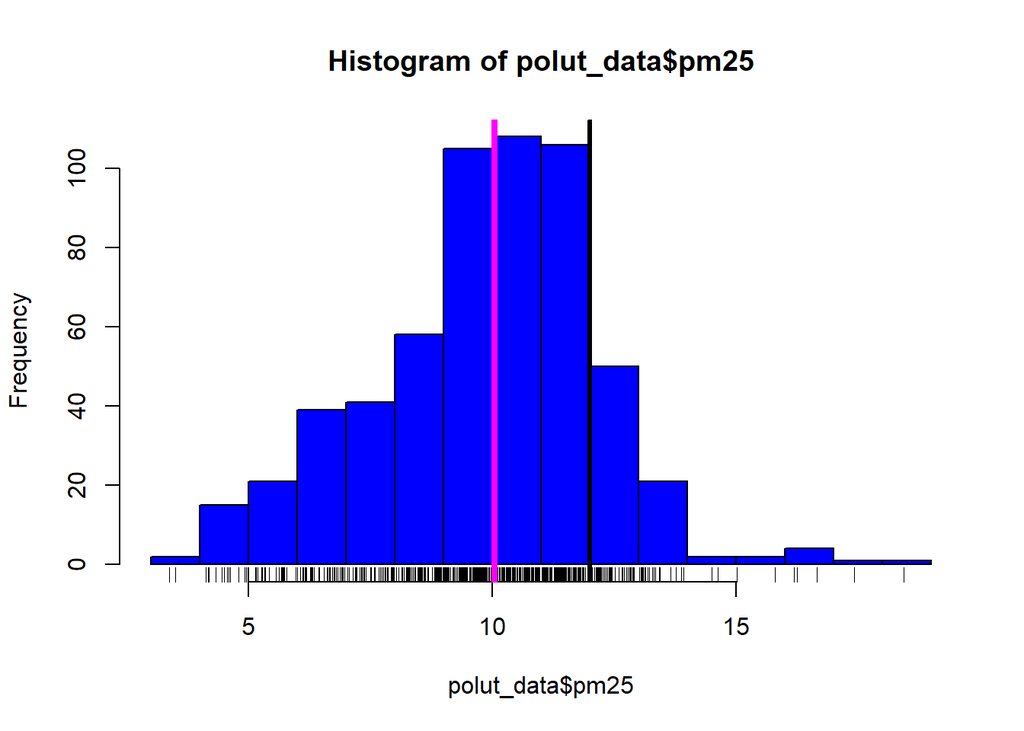

```r
hist(polut_data$pm25, col = "blue")
rug(polut_data$pm25)
abline(v = median(polut_data$pm25), col = "magenta", lwd = 4)
abline(v = 12, lwd = 3)
```

### Barplot

Illustrate the number of counties in each region - west and east

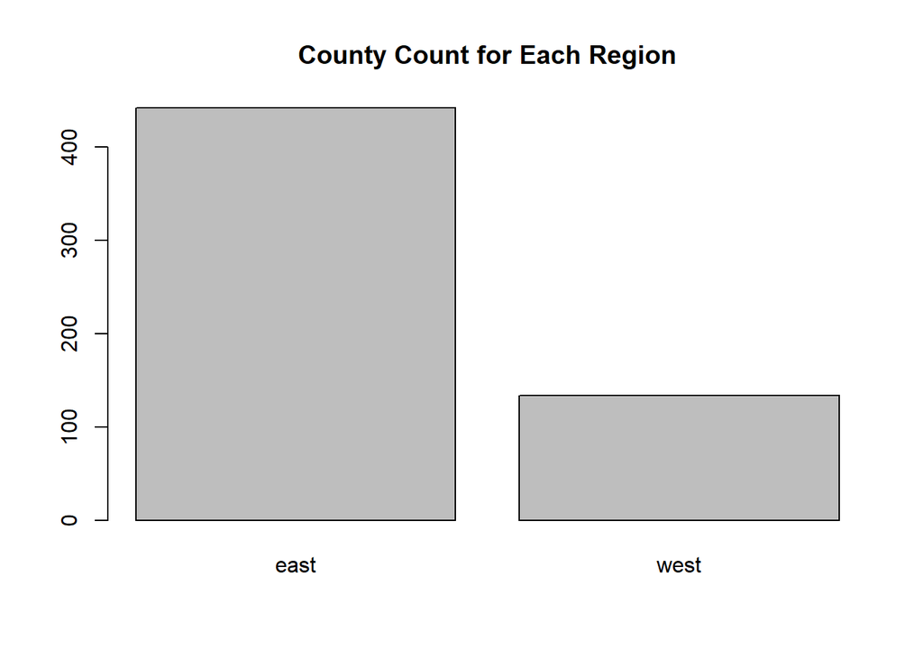

```r
region = polut_data$region
table(region) %>% barplot(col = "grey", main = "County Count for Each Region")
```

Difference in PM2.5 levels between the eastern and western parts of the U.S.

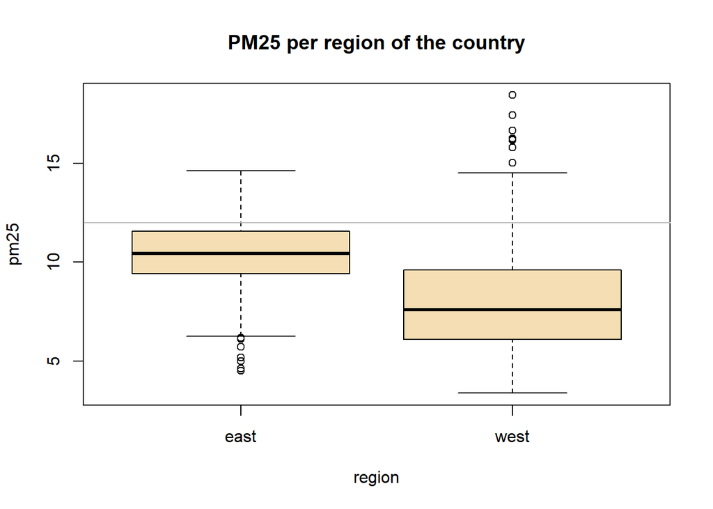

```r
boxplot(pm25 ~ region, data = polut_data, col = "wheat", main = "PM25 per region of the country")
abline(h = 12, col = "gray")
```

Plotting 2 histograms of PM25 for east and west regions separately

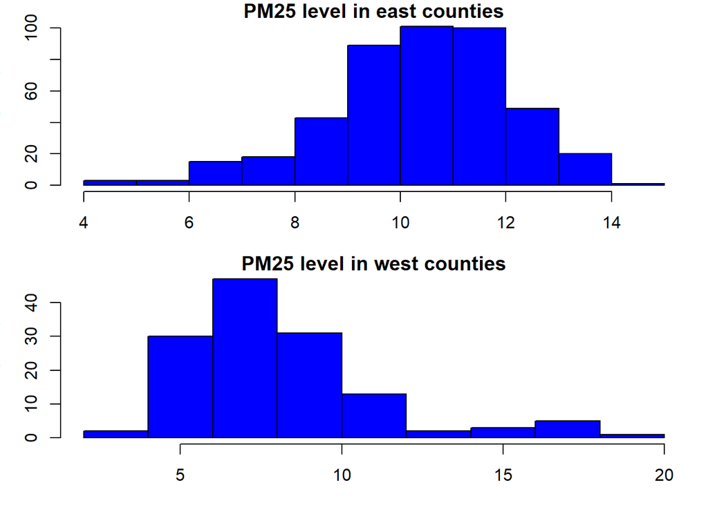

```r
# dividing data into regions
east = polut_data %>% filter(region =="east")
west = polut_data %>% filter (region == "west")

# set up the margins and location of the plot
par(mfrow = c(2,1), mar = c(3, 3, 1, 1))
# plot data for each region
hist(east$pm25, col = "blue", main = "PM25 level in east counties")
hist(west$pm25, col = "blue", main = "PM25 level in west counties")
```

### Scatterplots

`with` evaluates *“an R expression in an environment constructed from data”*.

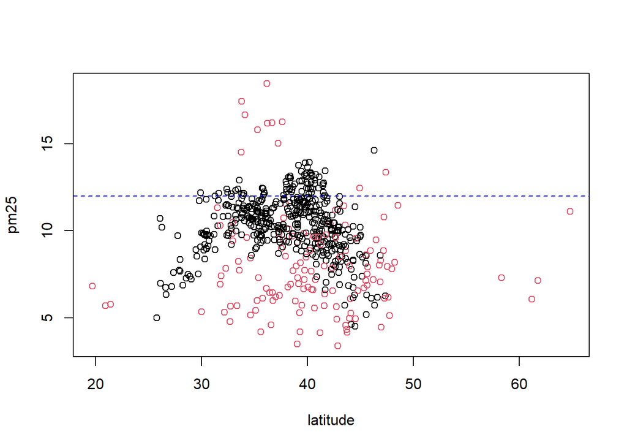

```r
# plot pm25 as a function of latitude per region
with(polut_data, plot(latitude, pm25, col = polut_data$region))
#lty defines the line style
abline(h = 12, col = "blue", lty = 2)
```

To see which region mapped on which color we have to look at factor levels because 1st level `col = 1` is black (the default color) and `col = 2` is red.

Compare east and west

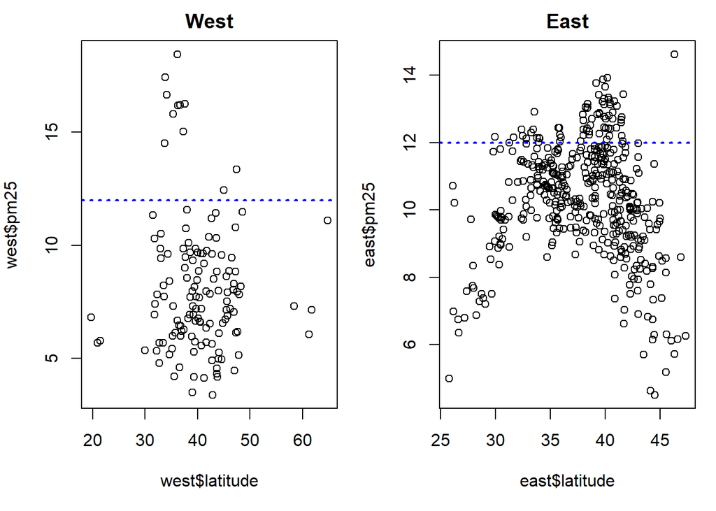

```r
par(mfrow = c(1, 2), mar = c(5, 4, 2, 1))

plot(west$latitude, west$pm25, main = "West")
abline(h = 12, col = "blue",lwd = 2,  lty = 3)
plot(east$latitude, east$pm25, main = "East")
abline(h = 12, col = "blue", lwd = 2, lty = 3)
```